# Activity monitoring analyses

Before performing analyses, read the data from the file:

First issue is calculating total number of steps taken each day. To get required value we’ll aggregate dataset ignoring (as long as it is allowed) NA values.

```r
setwd("~/RCoursera/Reproducible Research/CP_Reproducible_1")
data <- read.csv("activity.csv", stringsAsFactors=FALSE)
data[,2] <- as.POSIXct(data[,2], format="%Y-%m-%d")
data_a <- aggregate(data[,"steps"], list (Data = data$date), sum)
```

The histogram:

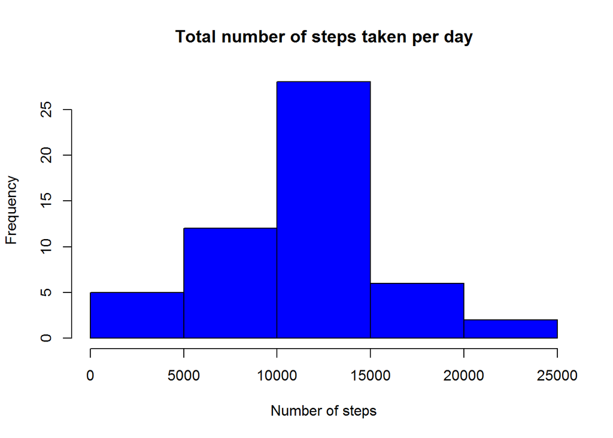

```r
hist(data_a$x, main = "Total number of steps taken per day", xlab = "Number of steps", col = 'blue')
```

Mean number of steps taken per day is following:

```r
mean_steps <- mean(na.omit(data_a$x))
mean_steps
```

```
## [1] 10766.19
```

Median for number of steps taken per day is following:

```r
median_steps <- median(data_a$x, na.rm = TRUE)
median_steps
```

```
## [1] 10765
```

```r
data_clean <- na.omit(data)
data_b <- aggregate(data_clean[,"steps"], list (Interval = data_clean$interval), mean)
```

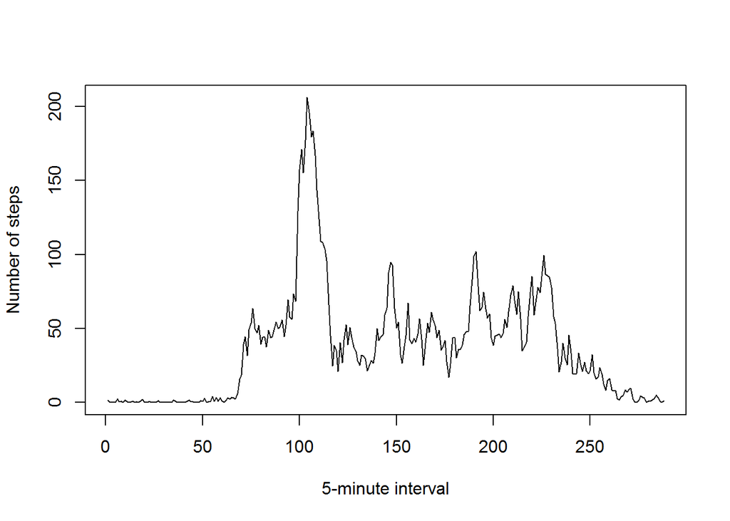

```r
plot(data_b$x, type = "l", ylab = "Number of steps", xlab = "5-minute interval")
```

Making an ordered dataframe to identify the interval with maximum number of steps

```r
b_sorted <- data_b[with(data_b, order(data_b$x, data_b$Interval, decreasing = TRUE)),]
b_sorted[1,"Interval"]
```

```
## [1] 835
```

Calculate and report the total number of missing values in the dataset (i.e. the total number of rows with NAs) In order to do this we just need to find the difference between clean dataset “data_clean” with omitted NAs and initial dataset “data@

```r
delta <- nrow(data) - nrow(data_clean)
delta
```

```
## [1] 2304
```

Creating a copy of initial dataset “data_full” for replacing missing values. Replacing each missing value for steps with the average number of steps for the corresponding 5 minute interval. Required values are already stored in data_b dataset.

```r
data_full <- data
for (i in 1:nrow(data_full)) if (is.na(data_full[i,"steps"])) data_full[i,"steps"] <- data_b$x[data_b$Interval == data_full[i,"interval"]]
head(data_full)
```

```
##       steps       date interval
## 1 1.7169811 2012-10-01        0
## 2 0.3396226 2012-10-01        5
## 3 0.1320755 2012-10-01       10
## 4 0.1509434 2012-10-01       15
## 5 0.0754717 2012-10-01       20
## 6 2.0943396 2012-10-01       25
```

Plotting a histogram, calculating total number of steps for processed dataset.

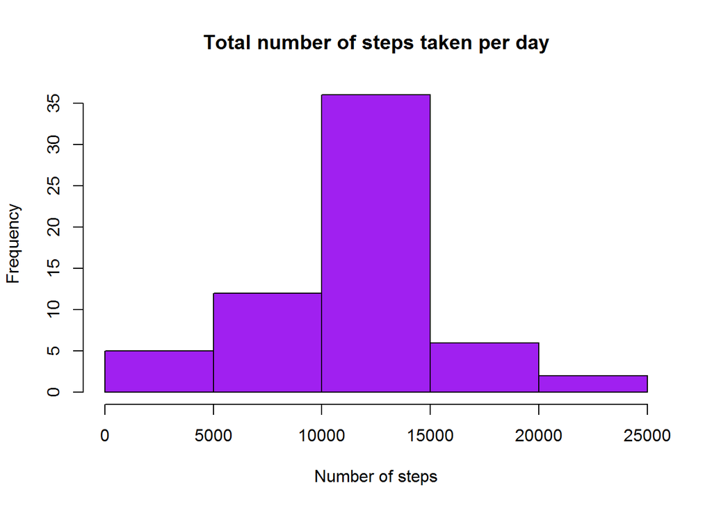

```r
data_a_full <- aggregate(data_full[,"steps"], list (Data = data_full$date), sum)
hist(data_a_full$x, main = "Total number of steps taken per day", xlab = "Number of steps", col = 'purple')
```

Calculating mean number of steps for full dataset

```r
mean_steps_full <- mean(data_a_full$x)
mean_steps_full
```

```
## [1] 10766.19
```

Calculating median for number of steps for full dataset

```r
median_steps_full <- median(data_a_full$x, na.rm = TRUE)
```

[output not shown]

In order to indicate weekdays and weekend we’ll first create vector, containing names of every week day. Then we’ll code them considering these names as “weekend” or “weekday” and transorm into factor variables. The last step is adding this vector to our dataset.

```r
wd <- weekdays(data_full$date)
for (i in 1:length(wd)) if (wd[i] == "суббота" | wd[i] == "воскресенье") wd[i] <- "weekend" else wd[i] <- "weekday"
wd <- as.factor(wd)
data_days <- cbind(data_full, wd)
data_days_ag <- aggregate(data_days[,"steps"], list (Int = data_days$interval, DT = data_days$wd), sum)
head(data_days_ag)
```

```
##   Int      DT          x
## 1   0 weekday 101.301887
## 2   5 weekday  20.037736
## 3  10 weekday   7.792453
## 4  15 weekday   8.905660
## 5  20 weekday   4.452830
## 6  25 weekday  71.566038
```

We have gotten the following plots:

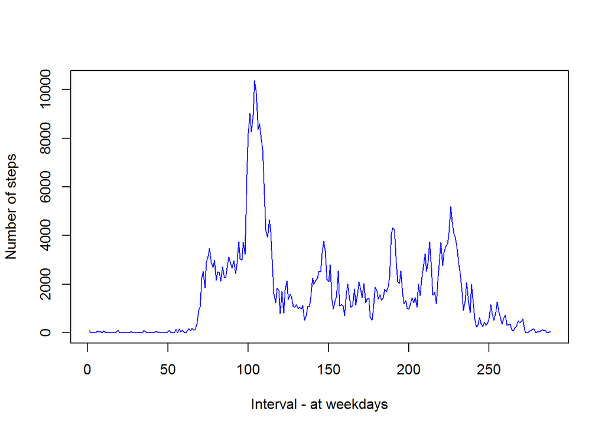

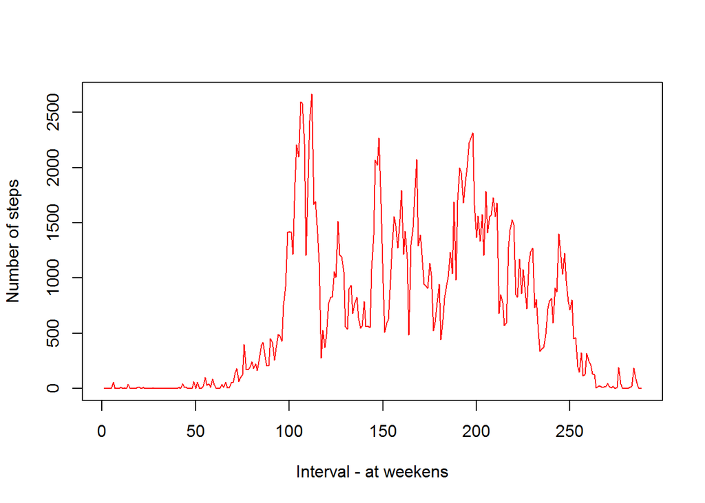

```r
with (data_days_ag,
      {plot(data_days_ag$x[DT == "weekday"], type = "l", xlab = "Interval - at weekdays", ylab = "Number of steps", col = "blue")
       plot(data_days_ag$x[DT == "weekend"], type = "l",  xlab = "Interval - at weekens", ylab = "Number of steps", col = "red")
       }
      )
```